# Beyond syntax, towards subculture: on the power and potentiality of deep open source communities

Steph

2018-05-17

# Introduction

R is a dynamic, vibrant programming language, going from strength to strength. Originally created by Ihaka and Gentleman in the 1990s, what was a niche experimental language is now in mainstream world-wide usage across many disciplines and domains (Ihaka, 1998).

One thing that Ihaka and Gentleman may not have intended at the time was the fact that R is no longer *just* a programming language. Users of R are developing into a distinct subculture at the intersection of multiple different fields and domains. This places it in a unique position, both to benefit from to influence those domains

This piece argues that not only is R a developing subculture: that being a subculture it can transmit and develop ideas that have a fundamental economic value beyond the coded output it enables. This piece also argues that not only does R as a subculture engender *value*, it creates, develops and demands *values*. A subculture developing in R does not just develop and transmit *ideas*, it develops and transmits an *ideaology*, one that has the potential to reach well beyond the fields and domains of its userbase.

# Not just a language

R is a programming language with two decades of development. In parallel to that programming development, community development has not only kept pace, but expanded rapidly in recent years. The R community is not bounded by any single institution, group or online platform. While there are large and distinct user groups - online and on the ground- on every continent: none of these wholly encompass the R community.

These communities, diverse and developing, share commonalities and crossovers that go beyond the programming language itself. They share distinctive patterns of behaviour, beliefs and mores. These should not be construed as a wholly *homogeneous* set of beliefs and behaviours: indeed, there are many differences between them. These differences can be considered subcultures within the common R subculture itself: R-Ladies has a distinctive difference in purpose to, the R community on Stack Overflow, for example: even though they share some of the same purpose. These are both different to the #rstats Twitter community and will be distinctly different to meetups in cities across the world.

Anheier et al. (2009) note that subcultures can exist at all levels of organisations. In other words, [xkcd was right, it’s fractal all the way down (xkcd, 2018)](https://xkcd.com/1095/). However, diverse groups share distinctive traits that tie them together.

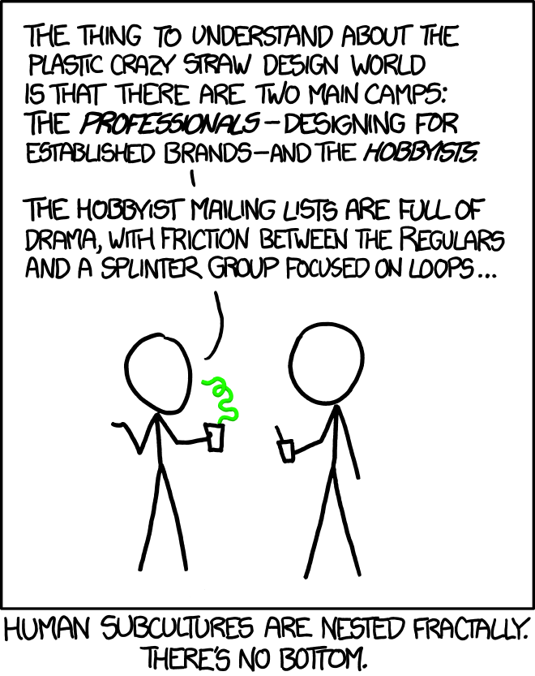

It’s fractal all the way down.

If we take the definition of a subculture as per Hodkinson (2012), these distinctive traits are *“…extra-ordinary in their location within the parameters and environment of unusually concentrated and often defiant communities centred on sets of styles and practices which, in some respects, are spectacular and distinctive and are understood as such both by insiders and outsiders.”* In the context of R, these are distinctive traits applied by others collectively *(“the R community is …”)* as well as those proudly championed in the community, for example, R’s own language quirks, notably the assignment operator <-.

The elements of a shared R lifeworld include:

**Shared institutions.** There are a number of institutions that R users regularly share with, participate in or benefited by. These include institutions critical to the functioning of R as a programming language, such as the R Core group, CRAN (Centralised R Archive Network), the R Journal and the R Foundation. However, participants in the developing subculture are not limited to these institutions: many R users attend local meetups and/or are involved in a remote community either through Twitter, StackOverflow or some other platform such as Meetup or Slack. Others in addition may identify with certain groups or ideologies such as R-Ladies, the Tidyverse (a complex subcultural phenomenon in itself) or other communities, like the R for Data Science learning community.

These institutions need not be formal, as CRAN or the R Journal are. They can be informal, but regular and expected methods of communication of ideas of import within the subculture, such as Mara Averick’s use of the Twitter platform to outreach and engage with R users who may not necessarily be a part of a tight-knit community. Informal methods of communication, such as the use of emoji signal to readers that the information to be conveyed is accessible. In a field where the communication of highly technical information can be difficult to propagate outside centres of shared technical language and concepts, this technique has been highly successful in propagating content outside the core subculture (Averick, 2018).

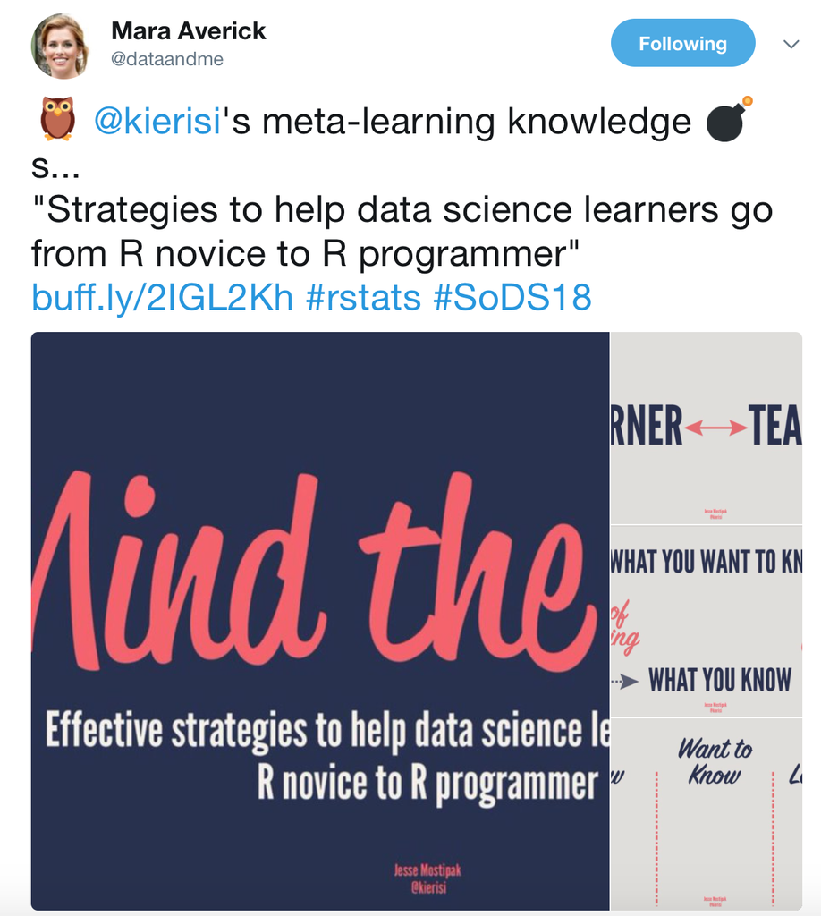

A distinctive visual style, easily accessible to the as-yet uninitiated.

**Distinct philosophical and well developed ideaological concepts**. While not espoused or recognised by every member of the community: many members grapple with, embrace or dispute with certain philosophies, most notably *‘the tidyverse’*. Indeed, there is a substantial differential of opinon within the developing subculture around the tidyverse, which paralells the experience Coleman (2012) observed among ‘hackers’ in the Debian project.

Domain-specific issues, such as the replicability crisis in psychology (see for example Pashler and Wagenmakers, 2012) have created deep ideaological discussions and responses from within the R community. Indeed, one of the most important institutions in the subculture, ROpensci, is predicated on improving the tools available to the subculture to manage reproducibility ( [ROpensci, 2018](https://ropensci.org/about/)).

Intellectual constructs like the *layered grammar of graphics* (Wickham, 2010) or the *grammar of data manipulation* (Wickham et al., 2017) contribute to overall meta constructs of programming and data agency.

**Content developed especially for consumption within subculture**. The developing subculture produces more than code for the use of analysts and analysis produced by R code. The developing subculture produces, both for its own consumption and those outside of it:

**Visualisation as art:** both deliberately (see for example [the R Graph Gallery, Holtz (2017)](https://www.r-graph-gallery.com/portfolio/data-art/) or [Flowing Data (Yau, 2018)](http://flowingdata.com)), and accidentally, shared for appreciative purposes (see for example [accidental aRT (Woo and Mudrak 2018)](http://accidental-art.tumblr.com)).

**Analysis for entertainment and general education:** for example Robinson’s (2016, 2017) [analysis of Trump’s tweets](http://varianceexplained.org/r/trump-tweets/) and [Meek and Averick (2017)](https://archervisualization.herokuapp.com) (although the site was built in D3, analysis was also conducted in R).

**Extensive educative materials and communities:** both for R, the programming language (see for example Bocek (2018), Maegan (2018) among many others), for the dynamic package sharing system, [such as Silge (2017)](https://juliasilge.com/blog/navigating-packages/) and for navigating the community itself, [such as Ellis (2017)](https://ropensci.org/blog/2017/06/23/community/).

__Meta cultural content:__ created for the purpose of alerting the subculture to these resources, such as [R-Bloggers](https://www.r-bloggers.com), [R Weekly](https://www.rweekly.org), and others of more formality such as the R Journal.

A well-developed lifeworld is not unique to R as a developing subculture among programming languages. The seminal work of Coleman (2012) first noted the development of a rich open source subculture within the Debian project. Coleman noted in particular the interplay between two competing ideaologies, those of individualism and collectivism, within the ‘hacker’ subculture, as exemplified by the Debian project.

She noted: *The belief in the value of individuality coupled with the constant need for the help of other hackers points to a subtle paradox that textures their social world. The tension between individualism and collectivism, in particular, is negotiated through the extremely well-developed and common penchant that hackers have for performing cleverness, whether through technological production or humor*

A point which many participants in the R community will find familiar: particularly as to the common occurence of cleverness through technological production and humour *at the same time* (see for example Averick and Meeks 2017).

We have established an R subculture is developing. Does a distinct developing R subculture matter? If so, what does it *mean*?

# With subculture comes value

A programming subculture is more than just syntax: it’s a confluence of institutions, inputs and a repeatable cycle of output and value generation. The development of a subculture is driving the development of R, the programming language and in reverse the same is true.

A subculture is a powerful means of generating and transmitting information: both scientific and values-driven. Subcultures have both formal and informal institutions that preserve its information and disperse it within and beyond the subculture. A common R subculture between disciplines helps reduce the intellectual isolation many work under and promotes an marketplace of ideas where good ones get better and great ones move far beyond their initial disciplinary home.

The fact that R is a subculture and not just a language matters because it’s a highly efficient way of diversifying both high level ideas and technical tools that allow us to extract and create value. The formal cultural institution CRAN easily facilitates world-wide use of tools created. A mix of other formal and informal institutions that lets participants in the lifeworld *know they exist*.

The fact that R as a developing subculture has a unique array of inputs is not surprising. This subculture is not only at the intersection of a very broad array of fields- it also provides a communication medium between them.

Software developers are powering the development of the language and in R, many of them come from non-traditional software engineering backgrounds, or no software engineering background at all.

Users (as distinct to creators of R the programming language) of R are even more diverse: while the language was intended as a statistical one, it now has scientific, engineering, economic applications, as well as important humanities and business ones.

However, it is the array of outputs from this developing subculture that is truly extraordinary. These could be roughly divided into three, non-exclusive, not necessarily consecutive stages:

**First stage outputs:** Improvements and additions to R itself. Packages, developments to the R base, integrated development environments (IDEs) etc.

**Second stage outputs:** Scientific, statistical and humanities work built in part using first stage outputs. The development of new statistical, data science or other scientific techniques, algorithms and models.

**Third stage outputs:** Work that uses these scientific and other research outputs to create other objects of value in the community - business uses, government use, applied scientific research, education, health etc.

Clearly there is an interplay between stages and being neither consecutive or even exhaustive, one piece of work can encompass all three stages.

The fact that open source has *value* is not new, e.g. Debian, Microsoft’s opposition to *FOSS*. But it’s not just the technology that is being created that is valuable: it’s an evolutionary tourney of ideas that a subculture gives rise to. The existence of a developing subculture brings value to the process of creation that extends beyond programmers coding alone or together. A subculture absorbs ideas from the outside, sets them to compete with each other, evolves them and generates new ones. This process, an evolutionary tourney of *ideas* has a real and intrinsic value.

Being at the intersection of multiple academic disciplines (statistics, ecology, biology, economics, engineering, computer science, sociology, politics to name a few), schools of thought (e.g. sciences, business, humanities) as well as practioners (academics, students, business, government) means an incredible confluence of ideas generated by this developing subculture.

These compete with and interact with one another, developing nuances, branches and new ideas themselves. This is inherently valuable.

The value that’s being driven by this tourney of ideas can be considered in three different types as a rough typology:

**Methodological sharing.** New methodologies as well as old ones not well known outside their specific fields can and are picked up, transmitted and pollinated across new fields with incredibly rapidity within this subculture.

**Ideaological sharing.** Ideaologies within the developing subculture are floated, debated, evolve and take root. These can include ideaologies around diversity, ethics and robust science (reproducibility amongst others).

**Strategy sharing.** Shared and devloping concepts around workflows, professionalising software development management techniques, programming norms and statistical/methodological skill contribute to a more robust workforce with a broader outlook, doing better analyses, faster and more productively.

A number of these R cultural outputs can translate into very substantive economic value simply by the productivity increases they engender for such a wide group users. They may seem prosaic, but because of the number of people they can help and apply to, their impacts are substantive. It’s also important to remember no subculture exists or works in isolation: many of these issues have influenced and been influenced by similar concerns among other programming subcultures.

Some of the ideas that have been developed and championed in the R community include:

**Visualisation.** While `ggplot2` owing to Wickham (2009) is possibly the most well known example, the base graphics functionality of R (R Core Team, 2017) helped create a new environment where visualisation was a key factor in the two critical components of creating value through data: the *finding* and *communication* of insights. However, the contribution of the subculture does not start and finish with provision of utilities. Critical to the usage of those utilities is the development of modes of usage and educating the developing subculture as to their value. Critical contributions to this field include the work of Cook (see for two examples, Unwin, Hofman and Cook (2013), Cook, Lee and Majumder (2016)) amongst many others.

**Designed workflows.** While workflows have always existed in some from for any data work, the value of a deliberate, strategically designed flow of work from project inception to completion has not had the wide acceptance in previous years it currently has. Championed by the R community, examples include simple and useful advice, casually applied (a single examplar being [Meager, 2018](https://twitter.com/economeager/status/997077103483981825)) to Bryan’s tour de force modernising, deliberately desiging and championing productive, efficient work practices. For a few examples, see Bryan (2017, 2018), Wickham and Bryan (2017), Bryan and Zhao (2017) to name a very few.

**Interoperability.** The R community has long been a champion of the concepts around interoperability: the need for R to be able to communicate with other platforms and for R users to be able to access data in many forms. Examples are many and varied, but include recent developments such as [Ursa Labs](http://wesmckinney.com/blog/announcing-ursalabs/) as well as critical packages of long standing such as Rcpp (Eddelbuettel and Francois 2011), rJava (Urbanek, 2016), to newer efforts such as Reticulate (Allaire, Tang and Geelnard 2018) and Tabulizer (Leeper, 2018). These are a few select examples among many critical ones.

**The value of diverse documentation.** The R community has long championed not just documentation, but diversity of documentation, recognising different learning styles. From vignettes, to videos, talks, blog posts, learning communities and Stack Overflow, the R language is increasingly richly documented, and these documents are propagated throughout the developing subculture as discussed above.

These four specific ideas are not the only things that are important within R subculture, but they have had a profound impact on the way we work and will continue to work into the future.

# With subculture comes *values*

The existence of a developing subculture creates value: both economically and in terms of art, humour and community. However, the confluence of ideas promoted by a developing subculture also brings with it *values*. A subculture transmits not just *ideas* but *ideaologies*. As a subculture, we have a shared common set of values and we are constantly initiating new users into those values as they start to learn and use R.

Coleman (2012) notes that this is not a monolithic ideaology in the hacker subculture exemplified by Debian, nor is it in the case in R. To quote Coleman, *“Once we recognise the intimate connection between hacker ethics and liberal commitments *and* the diversity of ethical positions, it is clear that hackers provide less of a unitary and distinguishable ethical position, and more of a mosaic and interconnected, but at times divergent ethical principles.”*

R as a subculture is dedicated to two broad ideas in particular: data agency, the ability to manipulate data at will, and data literacy, the ability to interpret the information it represents.

We are at a unique place in history to be a subculture with a viewpoint focussed on data. The data sciences are a powerful influence on a changing world. The power of a subsculture is that multiple diverging view points about a single development is possible and we are able to provide a robust, nuanced and debated view as a community.

As a subculture, part of broader subcultures of programming and the data sciences, we are aware of both the *value* of the new, as well as the need for *values* to utilise the new fairly.

The phenomenon of a subculture influencing the broader general culture in which it exists was well documented among the Debian hackers by Coleman. She noted, *“By turning Linux and open source into household names, many more people learned about not just open source but also the ethical foundations—sharing, freedom, and collaboration—of free software production.”* The Debian subculture directly participated in transitioning the view of open source software from unvaluable, unethical, unimportant, to the vibrant, essential and ethically bound technology it’s considered today.

The same is possible for R as a subculture in the future. We are at a crossroads where algorithmic decision making, data-driven automation and AI are all a part of our near futures. A strong subculture debates new advances, sees the economic value in them and develops an ethical framework to demand that that this value be distributed fairly, while ensuring the costs are not borne unfairly by a minority.

Ethical explorations are active in the R community. These include projects developed with the assistance of the ROpenSci foundation [such as that owing to Bailey (2018)](https://github.com/dynamicwebpaige/runconf18), and those created by individuals under their own ethical imperatives, such as those owing to Keyes ( [2016](https://ironholds.org/scientific-consent/) and [2017](https://ironholds.org/names-gender/)). [Keyes (2017b)](https://ironholds.org/not-about-image/) also explores how community management can create (or fail to create) an environment of diversity and inclusion: and that this has a direct ethical implication for a community at large.

The R community does not develop its ethics in isolation from the broader programming or data sciences communities. The community is also exploring confluences of consequences through online media such as Twitter. In one example, Thompson and Nemeth (2018), neither of whom appear to be R programmers, explored unintended ethical consequences in a post widely shared among data science communities, shown below.

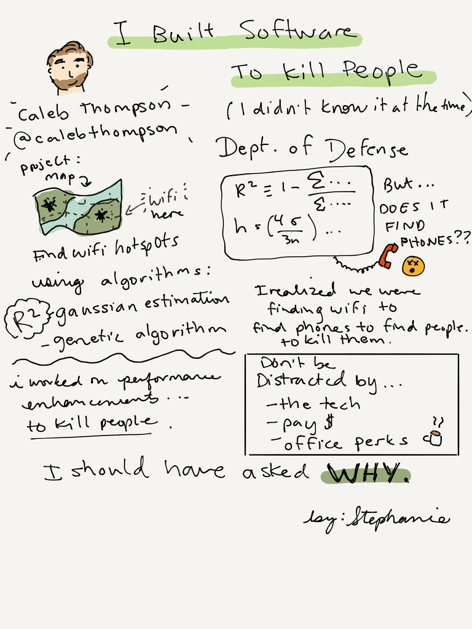

[Unforseen consequences, Thompson and Nemeth(2018)](https://twitter.com/stephaniecodes/status/992419444810010625)

In another widely shared example, Python user `@defsophiaray` (Soph, 2018), [noted the often unacknowledged biases of data collection and its unintended consequences on predictive algorithms](https://twitter.com/defsophiaray/status/996151795629125633), shown below. The issues of data-based policing are particularly pertinent world wide, see for example, [The Economist’s](https://www.economist.com/news/britain/21742151-over-third-those-named-it-have-no-serious-convictions-database-suspected-london?frsc=dg%7Ce) coverage of British gang activity databases (The Economist, 2018).

[figure not shown]

Neither data nor algorithms are neutral, Soph (2018)

These highly visible ethical explorations, shared widely within the R community, reinforce existing ethical norms, develop new ones and educate new members of the developing subculture of the expectations of the community.

R as a subculture creates *value*, but it also receives, develops and ultimately transmits its *values*. There are some values that have taken root in this developing subculture and are points of pride for many within the community:

**A place for new adopters.** Many in the R community see it as part of their participation in the community to be encouraging and welcoming to new users. Some go further and create diverse resources or host community events (online or otherwise) to support this aim.

**Open source.** As an open source programming language, the ethics of open source are ‘built in’ to the developing subculture. Many see contribution to open source development of R as part of their involvement with the subculture. They believe in creating new utilities for others to use and build on freely. CRAN is the most visible and important of the institutions supporting these values, but there are many others.

**Diversity and inclusion.** There is a developing awareness in the R community that not all members of the subculture have equal access to the meritocracy that the community believes in. Many programs and organisations have stepped up to begin the work of changing this, most notably R-Ladies amongst others.

**Reproducibility.** Originally a question of ensuring scientific contributions are accountable and testable, the importance of reproducibility now has much wider acceptance outside science and in the business community at large. Led in part by ROpenSci’s purpose of creating tools for reproducible science and the concept has been championed by Leek (2017, 2018), Leek and Peng (2015), amongst others.

The influence that commitment to these and other values may have on a developing subculture is not without precedent. In the case of Debian, Coleman (2012) notes that *“Over ten years of active development and use of free software, a critical mass of hackers had inculcated not simply a commitment to their craft but also a well-developed ethos for information freedom and sharing…”* In R’s case, it is possible that community commitment to these and other values will have similar effects at large.

The R community is a group of individuals collectively identifying as part of a whole. Each one contributes his, her or their values to the collective. This is the case whether the decision is made consciously and followed up by action or if no conscious thought is given to values individually or collectively. When conscious thought around values is missing, it is not the presence of an absence of values, rather an absence of the presence of thought for them.

Members of the subculture take these values with them into their workplaces and use them to make judgement decisions about the work they are doing. They are in turn influenced by the ethics in their workplaces and bring these back to the R community. This can create powerful change in the culture at large.

# Beyond syntax, conclusion

The R programming language has a vibrant, developing subculture attached to it. This subculture creates not just programming utilities, but art, educational artefacts, communities and research across many domains and fields. The subculture has championed ideas that have had a profound and valuable impact on the development of a modern analytics practice, namely visualisation, workflow, documentation and interoperability.

The presence of a subculture allows ideas to be inherited from other subcultures, altered, debated and built upon in a kind of ideaological evolutionary tourney. This goes beyond content created and into ideaology and values. As a community focussed on data agency and literacy, the developing subculture has the potential to be highly influential in the super culture in which it exists, being able to provide a nuanced, robust and multifaceted view of new technological developments.

# References

— (2018): “A database of suspected London gangsters has been widely shared”, *The Economist*, 18/05/10, https://www.economist.com/news/britain/21742151-over-third-those-named-it-have-no-serious-convictions-database-suspected-london?frsc=dg%7Ce, accessed 18/05/23.

Allaire, J.J., Tang, Y., Geelnard, M., 2018: *Reticulate: Interface to ‘Python’*, R package version 1.5, https://CRAN.R-project.org/package=reticulate.

Anheier, Helmut K., Stefan Toepler and Regina List, eds., (2010): *International Encyclopedia of Civil Society*, Springer New York.

Averick, M. (2018): *Twitter Post*, https://twitter.com/dataandme/status/999834698997170178, accessed 18/05/27.

Averick, M. and Meeks, E., (2017): *Beyond the Tip: A data-driven exploration of Archer*, https://archervisualization.herokuapp.com, accessed 18/05/21.

Bailey, P. (2018): *Ethical Machine Learning: A vignette designed to assist with spotting and preventing proxy bias*, https://github.com/dynamicwebpaige/runconf18, accessed 18/05/23.

Bocek, M., (2018): *Data Science Course in a Box*, https://github.com/rstudio-education/datascience-box, accessed 18/05/21.

Bryan, J., (2017): *Stat 545*, https://github.com/STAT545-UBC, acessed 18/05/22.

Bryan, J., (2018): *Happy Git and GitHub for the useR*, http://happygitwithr.com, accesed 18/05/22.

Bryan, J., Zhao, J., (2017): *googlesheets: Manage Google Spreadsheets from R*, R package version 0.2.2, https://CRAN.R-project.org/package=googlesheets.

Coleman, E.G., (2012): *Coding Freedom: The Ethics and Aesthetics of Hacking*, Princeton University Press, Princeton.

Cook, D., Lee, E-K., Majumder, M. (2016): “Data visualization and statistical graphics in big data analysis”," *Annual Review of Statistics and Its Application*, Volume 3, p. 133-159, https://www.annualreviews.org/doi/10.1146/annurev-statistics-041715-033420, accessed 18/05/22.

Eddelbuettel, D., Francois, R., (2011). “Rcpp: Seamless R and C++ Integration”, *Journal of Statistical Software*, Volume 40, Number 8, p. 1-18, http://www.jstatsoft.org/v40/i08/.

Ellis, S.E., (2017): “Hey! You there! You are welcome here”, *ROpenSci*, https://ropensci.org/blog/2017/06/23/community/, accessed 18/05/21.

Hodkinson, P., (2012): Beyond Spectacular Specifics in the Study of Youth (Sub)Cultures, *Journal of Youth Studies*, Volume 15, Issue 5.

Holtz, Y., (2018): *The R Graph Gallery* https://www.r-graph-gallery.com, accessed 18/05/21.

Ihaka, R., (1998): *R: Past and Future History*, https://www.stat.auckland.ac.nz/~ihaka/downloads/Interface98.pdf, accessed 18/05/21.

Keyes, O. (2016): “Ethics, scientific consent and OKCupid”, *Ironholds*, https://ironholds.org/scientific-consent/, accessed 18/05/23.

Keyes, O. (2017): “Stop Mapping Names to Gender”, *Ironholds*, https://ironholds.org/names-gender/, accessed 18/05/23.

Keys, O. (2017b): “Behaviour and Community in Open Science”, *Ironholds*, https://ironholds.org/not-about-image/, accessed 18/05/23.

Leek, J., (2017): “Reproducibility and replicability is a glossy science now so watch out for the hype”, *Simply Statistics*, https://simplystatistics.org/2017/03/02/rr-glossy/, accessed 2018/05/23.

Leek, J., (2018): “The value of re-analysis”, *Simply Statistics*, https://simplystatistics.org/2012/12/18/the-value-of-re-analysis/, accessed 2018/05/23.

Leek, J., Peng, R.D., (2015): “Opinion: Reproducible research can still be wrong: Adopting a prevention approach”, *Proceedings of the National Academy of Sciences of the United States of America*, Volume 112, Number 6, p. 1645-1646, http://www.pnas.org/content/112/6/1645, accessed 18/05/23.

Leeper, T., (2018): “Release ‘open’ data from their PDF prisons using tabulizer”, *ROpenSci*, https://ropensci.org/blog/2017/04/18/tabulizer/, accessed 18/05/22.

Maegan, J., (2018): *R4DS: the next iteration*, https://www.jessemaegan.com/post/r4ds-the-next-iteration/, acccessed 18/05/21.

McKinney, W., (2018): *Announcing Ursa Labs: an innovation lab for open source data science*, http://wesmckinney.com/blog/announcing-ursalabs/, accessed 18/05/22.

Meager, R., (2018): *Twitter post*, https://twitter.com/economeager/status/997077103483981825, accessed 18/05/22.

Pashler, H., Wagenmakers, E-J., (2012): “Editors’ Introduction to the Special Section on Replicability in Psychological Science: A Crisis of Confidence?”, *Perspectives on Psychological Science*, Volume 7, Issue 6, http://journals.sagepub.com/doi/10.1177/1745691612465253, accessed 18/05/27.

R Core Team, (2017): *R: A Language and Environment for Statistical Computing*, R Foundation for Statistical Computing, Vienna.

Robinson, D., (2016): “Text analysis of Trump’s tweets confirms he writes only the (angrier) Android half”, *Variance Explained*, http://varianceexplained.org/r/trump-tweets/, accessed 18/05/21.

Robinson, D., (2017): “Trump’s Android and iPhone tweets, one year later”, *Variance Explained*, http://varianceexplained.org/r/trump-followup/, accessed 18/05/21.

ROpensci (2018): “Our Vision and Missiong”, *ROpenSci*, https://ropensci.org/about/, accessed 18/05/27.

Silge, J., (2017): *Navigating the R Package Universe*, https://juliasilge.com/blog/navigating-packages/, acccessed 18/05/21.

Soph (2018): *Twitter status*, https://twitter.com/defsophiaray/status/996151795629125633, accessed 18/05/23.

Thompson, C., Nemeth, S. (2018): *I Built Software to Kill People*, https://twitter.com/stephaniecodes/status/992419444810010625, accessed 18/05/23.

Unwin, A., Hofmann, H., Cook, D., (2013): Let graphics tell the story - datasets in R, *The R Journal*, Volume 5, Issue 1, p. 117-129. https://journal.r-project.org/archive/2013/RJ-2013-012/RJ-2013-012.pdf, accessed 18/05/22.

Urbanek, S., (2016): *rJava: Low-Level R to Java Interface*, R package version 0.9-8, https://CRAN.R-project.org/package=rJava.

Wickham, H., (2009): *ggplot2: Elegant Graphics for Data Analysis*, Springer-Verlag New York.

Wickham, H., (2010): “A Layered Grammar of Graphics”, *Journal of Computational and Graphical Statistics*, Volume 19, Number 1, p. 3 - 28.

Wickham, H., Bryan, J., (2017): *readxl: Read Excel Files*, R package version 1.0.0, https://CRAN.R-project.org/package=readxl.

Wickham, H., Francois, R., Henry, L., Müller, K. (2017): *dplyr: A Grammar of Data Manipulation*, R package version 0.7.4, https://CRAN.R-project.org/package=dplyr.

Woo, K., Mudrak, E., *Accidental aRt*, http://accidental-art.tumblr.com, accessed 18/05/21.

Yau, N., (2018): *Flowing Data*, http://flowingdata.com, accessed 18/05/21.